# An Analysis of a Best Fitting Model Based on a Bike Share Training Data Set to Predict the Number of Riders

Edward Chang

December 12, 2019

```r
knitr::opts_chunk$set(echo = TRUE)
knitr::opts_chunk$set(fig.show = "hold")
knitr::opts_chunk$set(echo = TRUE, tidy.opts=list(width.cutoff=60), tidy=TRUE)
knitr::opts_chunk$set(cache = T)
```

# 1: **Download the data**

```r
# Code for 1 : Download the data

# Read in train.csv
data = read.csv("train.csv")
```

# 2: **Basic Exploratory Data Analysis**

```r
# Code for 2 : Basic Exploratory Data Analysis

# Get summary of the data set

# create factor categorizing each day by MTuWThFSaSu (this
# can help in identifying observations)
data$weekday = as.factor(weekdays(as.Date(data$datetime)))

{
    cat("Summary", "\n")
    print(summary(data))  # print summary
}
```

```
## Summary
##                 datetime        season     holiday     workingday
##  2011-01-01 00:00:00:    1   fall  :2733   No :10575   No :3474
##  2011-01-01 01:00:00:    1   spring:2686   Yes:  311   Yes:7412
##  2011-01-01 02:00:00:    1   summer:2733
##  2011-01-01 03:00:00:    1   winter:2734
##  2011-01-01 04:00:00:    1
##  2011-01-01 05:00:00:    1
##  (Other)            :10880
##                 weather          temp           atemp          humidity
##  Clear/Partly Cloudy:7192   Min.   : 0.82   Min.   : 0.76   Min.   :  0.00
##  Heavy Rain/Snow    :   1   1st Qu.:13.94   1st Qu.:16.66   1st Qu.: 47.00
##  Light Rain/Snow    : 859   Median :20.50   Median :24.24   Median : 62.00
##  Misty              :2834   Mean   :20.23   Mean   :23.66   Mean   : 61.89
##                             3rd Qu.:26.24   3rd Qu.:31.06   3rd Qu.: 77.00
##                             Max.   :41.00   Max.   :45.45   Max.   :100.00
##
##    windspeed          casual         registered        hour24
##  Min.   : 0.000   Min.   :  0.00   Min.   :  0.0   Min.   : 0.00
##  1st Qu.: 7.002   1st Qu.:  4.00   1st Qu.: 36.0   1st Qu.: 6.00
##  Median :12.998   Median : 17.00   Median :118.0   Median :12.00
##  Mean   :12.799   Mean   : 36.02   Mean   :155.6   Mean   :11.54
##  3rd Qu.:16.998   3rd Qu.: 49.00   3rd Qu.:222.0   3rd Qu.:18.00
##  Max.   :56.997   Max.   :367.00   Max.   :886.0   Max.   :23.00
##
##        yr            weekday
##  Min.   :2011   Friday   :1529
##  1st Qu.:2011   Monday   :1551
##  Median :2012   Saturday :1584
##  Mean   :2012   Sunday   :1579
##  3rd Qu.:2012   Thursday :1553
##  Max.   :2012   Tuesday  :1539
##                 Wednesday:1551
```

## Summary

Based off of the summary of the data, most of the data seems to be unproblematic. However, there is only one observation in the data set that has level 4 for `weather` (Heavy Rain + Ice Pallets + Thunderstorm + Mist, Snow + Fog), and this might make it hard to make a model that to accurately predict observations for this type of weather due to the lack of data for it.

## Histograms

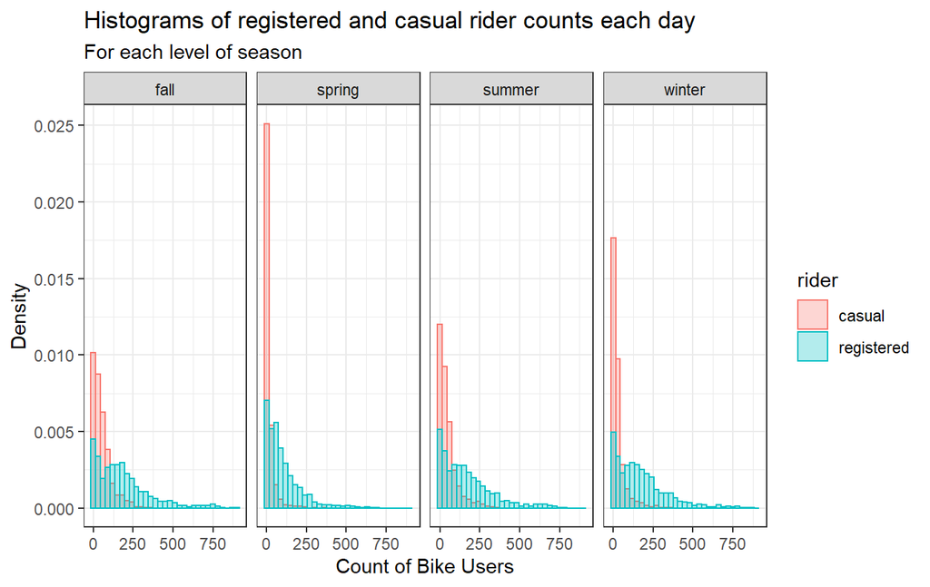

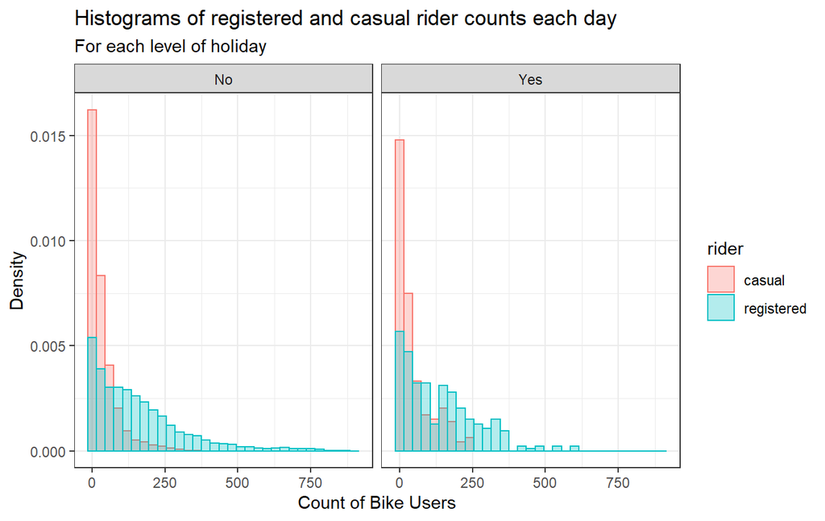

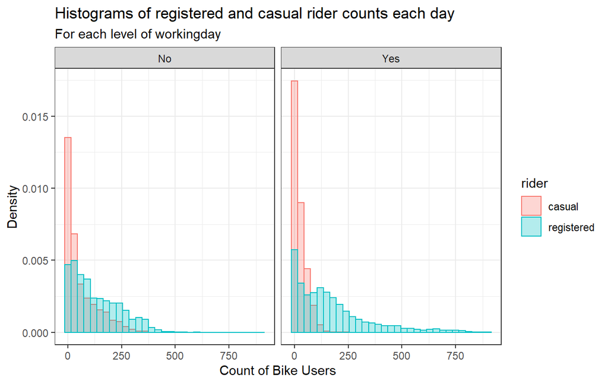

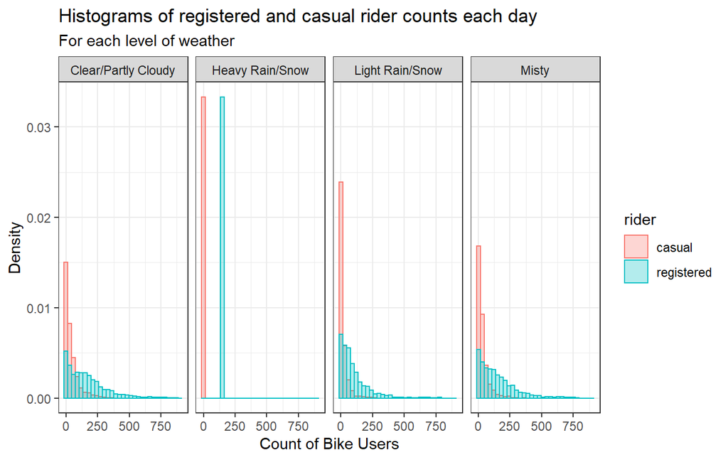

```r
require(ggplot2)  # use the ggplot2 package to create plots
require(tidyr)  # use tidyr package
# create a new dataframe where registered and casual counts
# are in the same variable, called `count`, and the variable
# `rider` either 'registered' or 'casual', depending on which
# of the original vectors it came from
dataStacked = gather(data, "rider", "count", casual, registered)

# create a histogram object for further use
registered_and_casual = ggplot(dataStacked) + geom_histogram(mapping = aes(x = count,
    y = ..density.., color = rider, fill = rider), position = "identity",
    alpha = 0.3, binwidth = 30) + labs(title = "Histograms of registered and casual rider counts each day",
    x = "Count of Bike Users", y = "Density") + theme_bw()

# create plots for each respective categorical variable in
# the data
registered_and_casual + facet_grid(~season) + labs(subtitle = "For each level of season")
registered_and_casual + facet_grid(~holiday) + labs(subtitle = "For each level of holiday")
registered_and_casual + facet_grid(~workingday) + labs(subtitle = "For each level of workingday")
registered_and_casual + facet_grid(~weather) + labs(subtitle = "For each level of weather")
```

The histograms for the season variable show that the registered rider counts generally show no change (proportion-wise) between seasons, most likely due to the fact that they are regular users of the service and use the bikes for commuting. However, we see that there are a lesser proportion of high counts of casual riders in the spring and the winter, with the spring having the least proportion.

The histograms for the holiday variable appear to show that are a slightly higher proportion of casual rider counts on holidays than on non-holidays; the registered proportions do not seem to show any significant change.

The histograms for the workingday variable show that on working days, there is a lesser proportion of casual rider counts counts and a higher proportion registered counts. This is probably because there would be less casual riders on working days and more registered riders who use the bikes for commuting purposes.

## Pairs plot

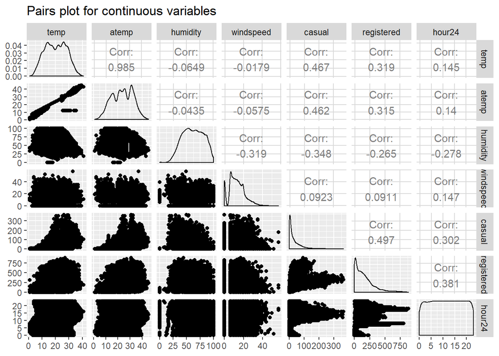

```r
# create a pairs plot
require(GGally)  # use GGally for coherent graphics throughout the project
ggpairs(data[, 6:12], progress = F, title = "Pairs plot for continuous variables")
```

From the pairs plot, many of the explanatory variables have little to moderate correlation with each other with the exception of the `temp` and `atemp` relationship, which is extremely high and is expected due to their nature of being measures of the temperature. We also see that on the plots where casual and registered are the response variables, that their graphs seem to change in the same general fashion. When temperature is low, casual and registered are low; when humidity is very high, the counts seem to plummet; when windspeed is high, the counts are low. From the hour24 plots, its nice to note that the temp and atemp graphs assume sinuous characteristics, and that around 5-10 am and 15-17, registered counts peak and for the casual counts, they peak around noon.

The blob of points on the temp/atemp plot is extremely interesting because they deviate from the main trend and create their own group. Analyzing this blob with a summary might give more insight. In addition, having 0 humidity seems to be abnormal, so analyzing data summary corresponding to that is important. Analyzing 0 windspeed might show something significant, that will be done too.

```r
# check atemp observation as noted in pair plot section
{
    cat("Summary for abnormal atemp observations", "\n")
    print(summary(data[data$temp > 20 & data$atemp < 15, ]))
}
```

```
## Summary for abnormal atemp observations
##                 datetime     season   holiday  workingday
##  2012-08-17 00:00:00: 1   fall  :24   No :24   No : 0
##  2012-08-17 01:00:00: 1   spring: 0   Yes: 0   Yes:24
##  2012-08-17 02:00:00: 1   summer: 0
##  2012-08-17 03:00:00: 1   winter: 0
##  2012-08-17 04:00:00: 1
##  2012-08-17 05:00:00: 1
##  (Other)            :18
##                 weather        temp           atemp          humidity
##  Clear/Partly Cloudy:17   Min.   :25.42   Min.   :12.12   Min.   :30.00
##  Heavy Rain/Snow    : 0   1st Qu.:26.86   1st Qu.:12.12   1st Qu.:40.25
##  Light Rain/Snow    : 2   Median :28.29   Median :12.12   Median :58.00
##  Misty              : 5   Mean   :29.66   Mean   :12.12   Mean   :57.08
##                           3rd Qu.:33.62   3rd Qu.:12.12   3rd Qu.:70.00
##                           Max.   :35.26   Max.   :12.12   Max.   :83.00
##
##    windspeed          casual         registered         hour24
##  Min.   : 7.002   Min.   :  0.00   Min.   :  6.00   Min.   : 0.00
##  1st Qu.: 8.998   1st Qu.: 14.75   1st Qu.: 91.75   1st Qu.: 5.75
##  Median :14.000   Median : 57.50   Median :202.50   Median :11.50
##  Mean   :15.501   Mean   : 61.79   Mean   :236.04   Mean   :11.50
##  3rd Qu.:20.500   3rd Qu.:104.25   3rd Qu.:332.00   3rd Qu.:17.25
##  Max.   :31.001   Max.   :144.00   Max.   :647.00   Max.   :23.00
##
##        yr            weekday
##  Min.   :2012   Friday   :24
##  1st Qu.:2012   Monday   : 0
##  Median :2012   Saturday : 0
##  Mean   :2012   Sunday   : 0
##  3rd Qu.:2012   Thursday : 0
##  Max.   :2012   Tuesday  : 0
##                 Wednesday: 0
```

- The summary of the selected blob on the abnormal `atemp` and `temp` cluster shows that the cluster is all from the same day yet `temp` changes while `atemp` doesn’t change the entire day. This indicates that there was an abnormality in the temperature taking systems in this day and removing them will remove outliers for `atemp` as well as improve modeling.

```r
# check humidity observation as noted in pair plot section
{
    cat("Summary for 0 humidity observations", "\n")
    print(summary(data[data$humidity == 0, ]))
}
```

```
## Summary for 0 humidity observations
##                 datetime     season   holiday  workingday
##  2011-03-10 00:00:00: 1   fall  : 0   No :22   No : 0
##  2011-03-10 01:00:00: 1   spring:22   Yes: 0   Yes:22
##  2011-03-10 02:00:00: 1   summer: 0
##  2011-03-10 05:00:00: 1   winter: 0
##  2011-03-10 06:00:00: 1
##  2011-03-10 07:00:00: 1
##  (Other)            :16
##                 weather        temp           atemp          humidity
##  Clear/Partly Cloudy: 0   Min.   :13.94   Min.   :15.91   Min.   :0
##  Heavy Rain/Snow    : 0   1st Qu.:14.76   1st Qu.:16.86   1st Qu.:0
##  Light Rain/Snow    :20   Median :15.99   Median :20.07   Median :0
##  Misty              : 2   Mean   :15.95   Mean   :19.28   Mean   :0
##                           3rd Qu.:17.22   3rd Qu.:21.21   3rd Qu.:0
##                           Max.   :18.04   Max.   :21.97   Max.   :0
##
##    windspeed          casual        registered         hour24
##  Min.   : 6.003   Min.   :0.000   Min.   :  0.00   Min.   : 0.00
##  1st Qu.:15.001   1st Qu.:1.000   1st Qu.: 11.00   1st Qu.: 7.25
##  Median :16.998   Median :1.000   Median : 21.50   Median :12.50
##  Mean   :17.546   Mean   :2.091   Mean   : 26.23   Mean   :12.23
##  3rd Qu.:19.750   3rd Qu.:3.000   3rd Qu.: 30.00   3rd Qu.:17.75
##  Max.   :39.001   Max.   :9.000   Max.   :109.00   Max.   :23.00
##
##        yr            weekday
##  Min.   :2011   Friday   : 0
##  1st Qu.:2011   Monday   : 0
##  Median :2011   Saturday : 0
##  Mean   :2011   Sunday   : 0
##  3rd Qu.:2011   Thursday :22
##  Max.   :2011   Tuesday  : 0
##                 Wednesday: 0
```

- Likewise, the observations with 0 humidity also show that they are on the same day, which is an obvious outlier measurement-wise because it should at least be variable when the temperature on that day did not reach 0 degrees. These observations will be removed.

```r
# check windspeed observation as noted in pair plot section
{
    cat("Summary for 0 windspeed observations", "\n")
    print(summary(data[data$windspeed == 0, ]))
}
```

```
## Summary for 0 windspeed observations
##                 datetime       season    holiday    workingday
##  2011-01-01 00:00:00:   1   fall  :350   No :1272   No :411
##  2011-01-01 01:00:00:   1   spring:263   Yes:  41   Yes:902
##  2011-01-01 02:00:00:   1   summer:268
##  2011-01-01 03:00:00:   1   winter:432
##  2011-01-01 04:00:00:   1
##  2011-01-01 06:00:00:   1
##  (Other)            :1307
##                 weather         temp           atemp           humidity
##  Clear/Partly Cloudy:901   Min.   : 2.46   Min.   : 5.305   Min.   : 17.00
##  Heavy Rain/Snow    :  0   1st Qu.:13.12   1st Qu.:17.425   1st Qu.: 54.00
##  Light Rain/Snow    : 74   Median :19.68   Median :23.485   Median : 71.00
##  Misty              :338   Mean   :19.80   Mean   :23.828   Mean   : 68.13
##                            3rd Qu.:26.24   3rd Qu.:30.305   3rd Qu.: 83.00
##                            Max.   :39.36   Max.   :43.180   Max.   :100.00
##
##    windspeed     casual         registered        hour24             yr
##  Min.   :0   Min.   :  0.00   Min.   :  0.0   Min.   : 0.000   Min.   :2011
##  1st Qu.:0   1st Qu.:  2.00   1st Qu.: 19.0   1st Qu.: 4.000   1st Qu.:2011
##  Median :0   Median : 10.00   Median : 91.0   Median : 8.000   Median :2011
##  Mean   :0   Mean   : 29.81   Mean   :131.3   Mean   : 9.899   Mean   :2011
##  3rd Qu.:0   3rd Qu.: 36.00   3rd Qu.:196.0   3rd Qu.:16.000   3rd Qu.:2012
##  Max.   :0   Max.   :367.00   Max.   :833.0   Max.   :23.000   Max.   :2012
##
##       weekday
##  Friday   :206
##  Monday   :181
##  Saturday :189
##  Sunday   :181
##  Thursday :172
##  Tuesday  :167
##  Wednesday:217
```

- The observations with 0 windspeed seem to be normal, and according to some searches, 0 windspeed indicates calm and is normally done so by the anemometers’ own systems.

## Time series plot

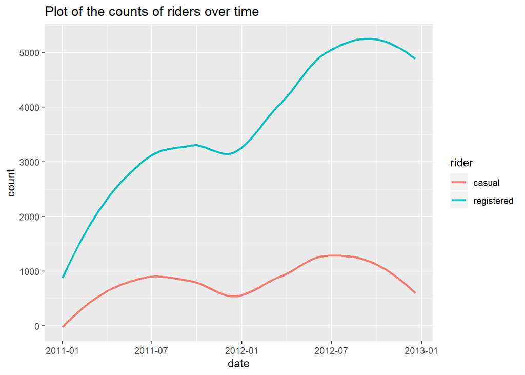

```r
# plot time series - change in casual/registered counts over
# time
require(dplyr)
# aggregate data to get total counts per day
data.agg = aggregate(data[c(10, 11)], by = list(date = as.Date(data$date)),
    FUN = sum)
# stack the data frame observations
data.agg.stacked = gather(data.agg, "rider", "count", registered,
    casual)
ggplot(data.agg.stacked, aes(x = date, y = count, col = rider)) +
    geom_smooth(se = F) + labs(title = "Plot of the counts of riders over time")
```

Generally, the counts of riders increase per year and follow a sinuous pattern, where the beginning of a year has less riders, the riders peak around fall, then they level down a little. Because of this sinuous patter, season and yr seem to have a big effect on the counts of the riders. However, we can see that the counts for casual riders vary little between year and do not peak that high in comparison to its local minimums.

## Heatmap

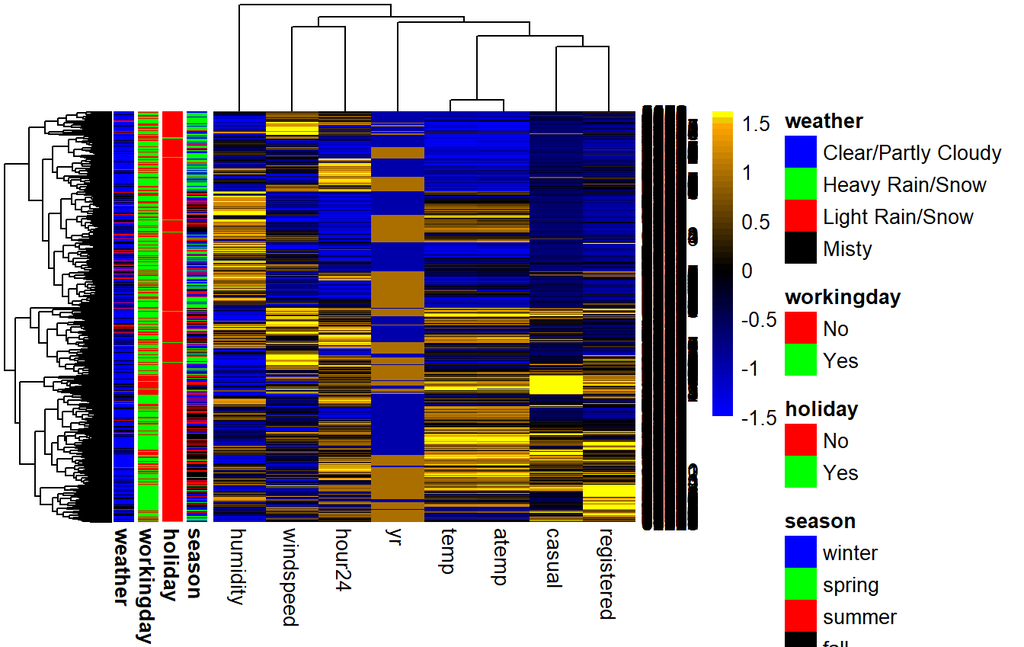

```r
# start to construct a heat map with annotation and scaling
require(pheatmap)
# create colors
seqPal <- colorRampPalette(c("orange", "black", "blue"))(50)
seqPal <- (c("yellow", "gold2", seqPal))
seqPal <- rev(seqPal)
colSeason <- c("Blue", "Green", "Red", "Black")
names(colSeason) <- c("winter", "spring", "summer", "fall")
colHoliday = c("red", "green")
names(colHoliday) = c("No", "Yes")
colWorkingDay = c("red", "green")
names(colWorkingDay) = c("No", "Yes")
colWeather = c("Blue", "Green", "Red", "Black")
names(colWeather) = c(levels(data$weather))

# scale data
dataScaled = data.frame(apply(data[, sapply(data, function(x) is.numeric(x))],
    2, scale))
# data frame for categorical data
dataCat = data[, !sapply(data, function(x) is.numeric(x))]
row.names(dataScaled) = row.names(data)
# find breakpoints and only for the 90% data in middle
qnt = quantile(as.numeric(data.matrix((dataScaled))), probs = c(0.05,
    0.95))
breakpoints = seq(qnt[1], qnt[2], length = length(seqPal) + 1)
# create heatmap
pheatmap(dataScaled, col = seqPal, scale = "column", breaks = breakpoints,
    annotation_row = dataCat[, c(-1, -6)], annotation_colors = list(holiday = colHoliday,
        workingday = colWorkingDay, weather = colWeather, season = colSeason))
```

The heatmap also shows some how the variables interact with each other. Besides the obvious correlations (`atemp` and `temp` or `registered` and `casual` or `season` and `temp`/`atemp`), we can see some previous things that were noticed on the histograms, casual and registered roughly change according to workingday as well as weather. Other than those, it is hard to clearly tell further things from the heatmap.

# 3: **Regression Analysis**

Note : For the following sections, I will be removing several observations that were noted in the previous Pairs plot section to inconsistent with the rest of the data and these were most likely due to errors in data collecting instruments.

Also, the `datetime` variable will not be used and `yr` and `hour24` will be used in place of it; `weekday` was also only created for EDA purposes to differentiate between days, but it will not be used for this section.

```r
# exclude observations from data set
data = data[!(data$temp > 20 & data$atemp < 15), ]
data = data[!(data$humidity == 0), ]
```

## Casual Variable

First, I will do regression on the `casual` variable.

The first regression that will be attempted is finding a simple model with no interactions just to get a base in seeing how the model would be like.

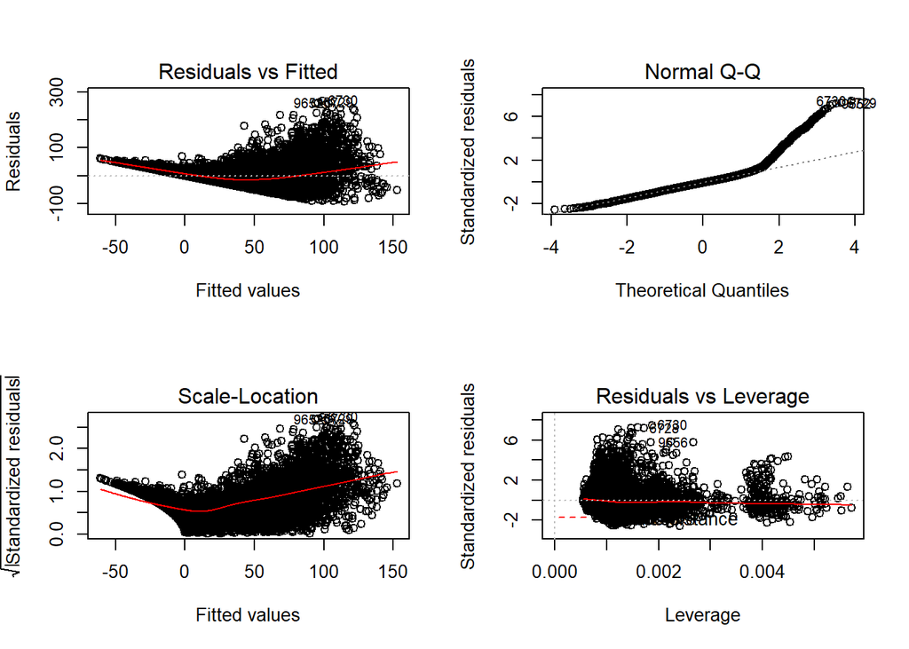

```r
# first casual fit with nothing
casual.fit1 = lm(casual ~ ., data = data[, c(-1, -14, -11)])

par(mfrow = c(2, 2))
plot(casual.fit1)
```

Based on the plots, it it’s clear that the right side of the fitted values do not follow the normal curve, so a tranformation can easily fix this (to an extent), and we can also observe its effect on the residual vs fitted plot. Specifically, `log(casual + 1)` will be used. Because some of the observations have 0 count, `+1` is neccessary to allow the `log` function to map the value. `log` is used because there are many values that deviate from the normal curve, and it should be able to bring most of the observations to proximity to the normal curve.

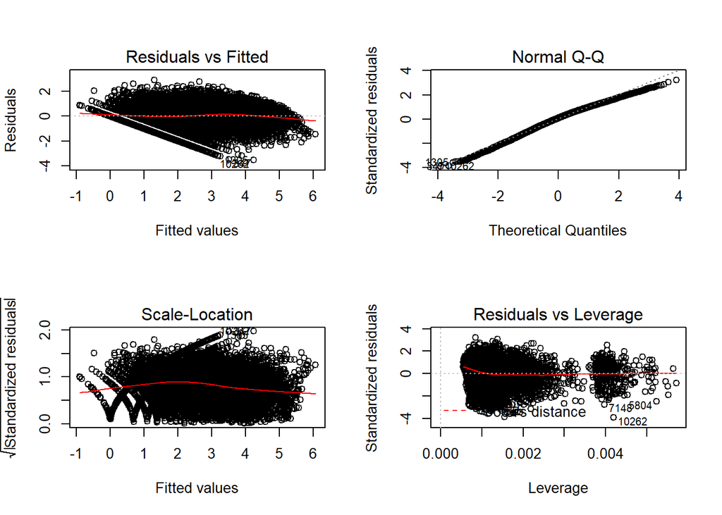

```r
# second casual fit with transformation
casual.fit2 = lm(log(casual + 1) ~ ., data = data[, c(-1, -14,
    -11)])

par(mfrow = c(2, 2))
plot(casual.fit2)
```

The transformation makes it clear that there are several observations which create a regular pattern in the residual vs fitted plots. Based on what we see in these plots, it might be reasonable to say that the residuals vs fitted plots are composed of a multitude of these patterns and probably caused by some aspect that the data is composed of observations over time.

The second regression that will be attempted is using all the variables and their interaction with the categorical variables, this is because at first glance, the categorical variables seem to have a major effect on the distributions of responses, so using the interactions might give a good model. The only exception is that yr appears to only affect the counts by a static amount, so I will leave that variable without any interactions.

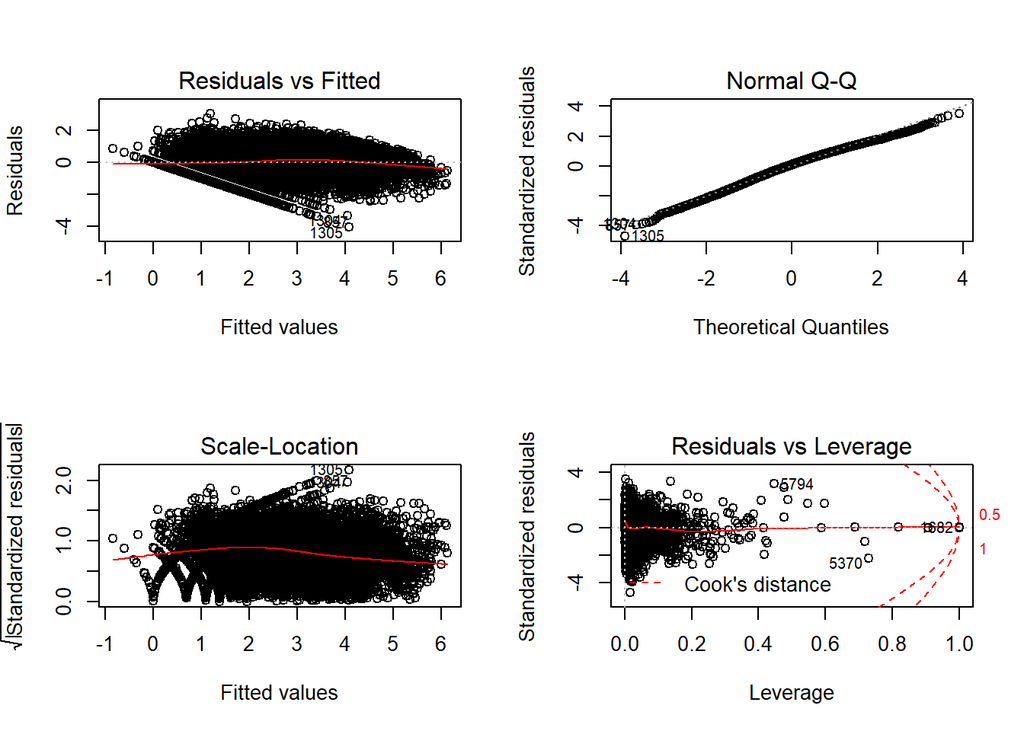

```r
# third casual fit with interactions
casual.fit3 = lm(log(casual + 1) ~ (. - season - workingday -
    holiday - weather - yr) * (season * holiday * workingday *
    weather) + yr, data = data[, c(-1, -14, -11)])

par(mfrow = c(2, 2))
plot(casual.fit3)
```

There is not much change in the residuals graph compared to the previous model, however the residuals vs leverage graph has changed considerably; more observations are being given more leverage. Next, I’ll try interactions somewhat based on the clustering in the heatmap and the patterns seen in the histograms that were constructed.

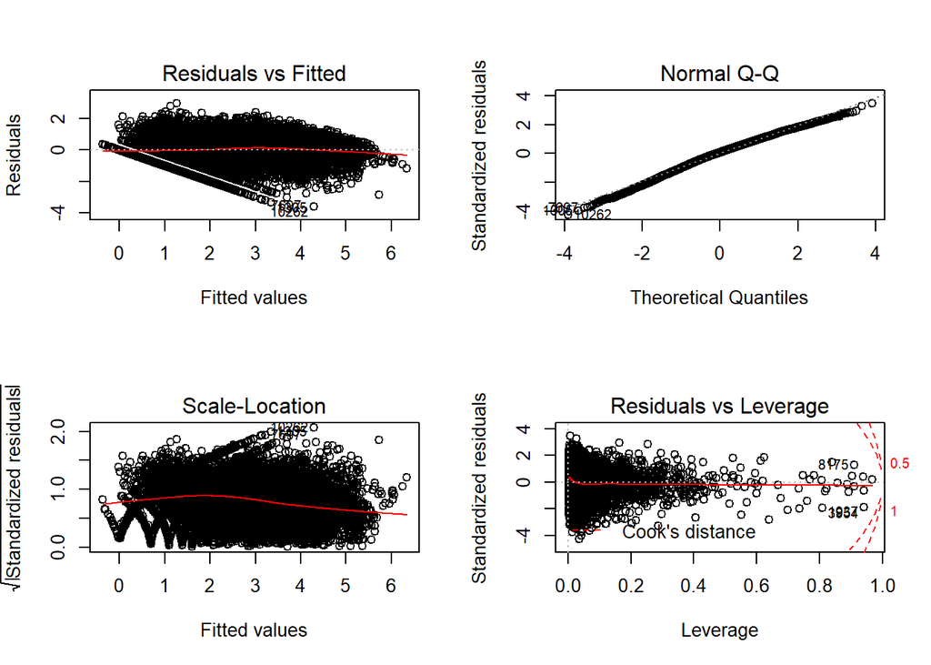

```r
# fourth casual fit wtih more interactions
casual.fit4 = lm(log(casual + 1) ~ ((temp + atemp) * yr * season) *
    (windspeed + hour24) * humidity * weather + workingday +
    holiday, data = data[, c(-1, -14, -11)])

par(mfrow = c(2, 2))
plot(casual.fit4)
```

It appears that nothing much changes even with the changes that I make to the interactions, so I will use the second model that I fitted with a transformation for my final model. I considered using $R^{2}$ as a measure of how well a model fitted, however, it would naturally increase with more interactions because more variables are added into the model. In addition, this model had less leverage for the points, it would seem better to use this since the residuals vs fitted had the same shape as the other models with interactions added. I am not using the very first model due to the extreme deviation from the normal curve as shown in its normal q-q plot. The few outliers that are flagged will also be removed from the data since it looks like they deviate from the bulk of the data.

```r
# create final casual fit with outliers omitted
casual.final = lm(log(casual + 1) ~ ., data = data[!(rownames(data) %in%
    c("10262", "7148", "5804")), c(-1, -14, -11)])
```

## Registered Variable

Now, I will perform regression with the `registered` variable as the response variable and follow the same patterns as the previous regressions I did with `casual`. I suspect that the response will again need a transformation, so I apply it for the first model that I fit.

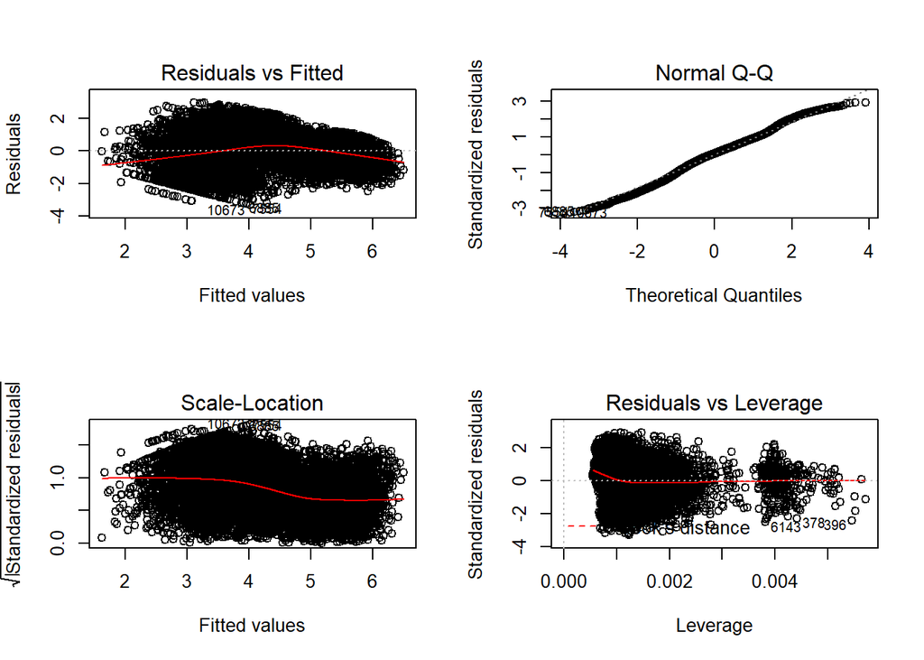

```r
# first registered fit with no interactions, but with
# transformation
registered.fit1 = lm(log(registered + 1) ~ ., data = data[, c(-1,
    -10, -14)])

par(mfrow = c(2, 2))
plot(registered.fit1)
```

It appears that the similar results are obtained compared to regression with the casual variable, however, the same check mark pattern in the casual regressions does not seem to be present in the registered variable. I’ll see if I can improve my fit by using the same interactions as my regressions with the casual variable.

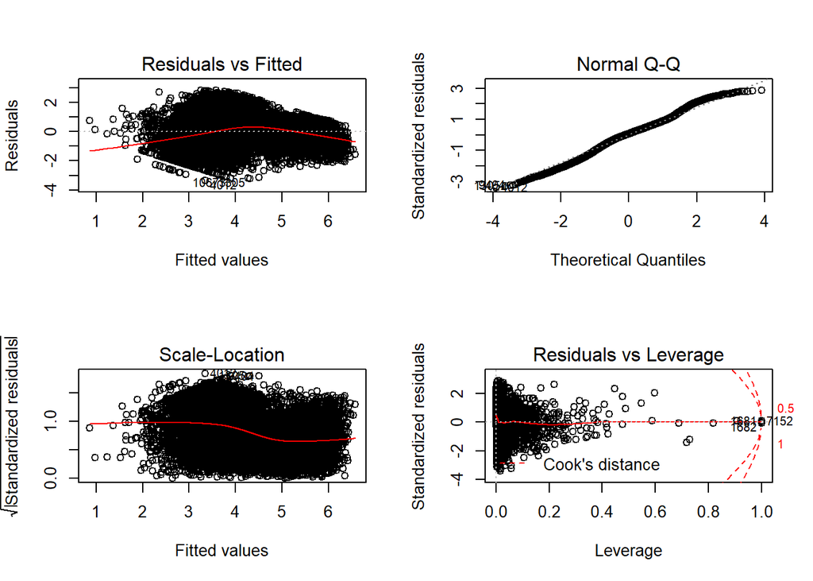

```r
# second registered fit with interactions
registered.fit2 = lm(log(registered + 1) ~ (. - season - workingday -
    holiday - weather - yr) * (season * holiday * workingday *
    weather) + yr, data = data[, c(-1, -14, -10)])

par(mfrow = c(2, 2))
plot(registered.fit2)
```

It seems that the fit has somewhat worsened; the Normal Q-Q shows that the average of the residuals seem to deviate more from the normal curve, and the leverage for many points has increased. This fit has also created observations with 1 leverage, so it seems that I’ll continue to try the same type of model that I fitted for `casual`.

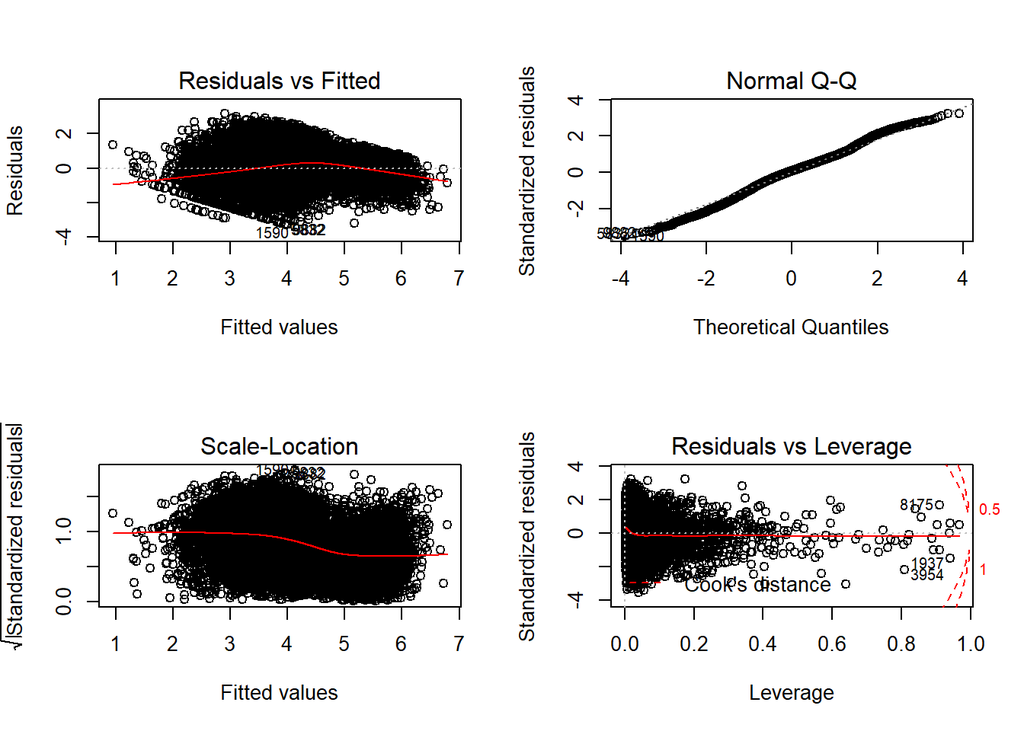

```r
# third registered fit with more interactions
registered.fit3 = lm(log(registered + 1) ~ ((temp + atemp) *
    yr * season) * (windspeed + hour24) * humidity * weather +
    workingday + holiday, data = data[, c(-1, -14, -10)])

par(mfrow = c(2, 2))
plot(registered.fit3)
```

The fit is similar the previous one, however the leverages have increased more (but there seems to have been no leverage one observations because R didn’t prompt it). Because I observe similar patterns in the graphs as with the `casual` regressions, I’ll be using the same reasoning as with the `casual` final model to use the first model that I fitted and without the flagged outliers as my final model.

```r
# create final registered fit object with outliers omited
registered.final = lm(log(registered + 1) ~ ., data = data[!(rownames(data) %in%
    c("6143", "378", "396")), c(-1, -10, -14)])
```

# 4: **Regression Diagnostics / Choice of response in regression**

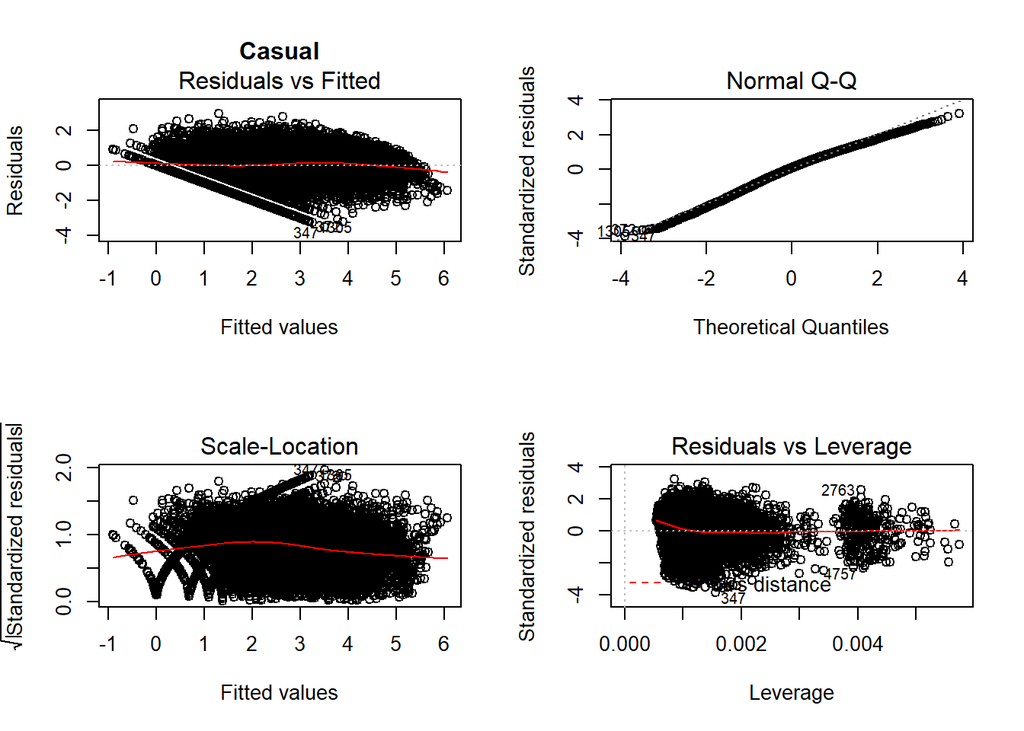

```r
# plot diagnostic plots for the final models, with titles to
# differentiate between the two models plot casual
{
    par(mfrow = c(2, 2))
    plot(casual.final, 1)
    title(main = "Casual")
    plot(casual.final, c(2, 3, 5))
}
```

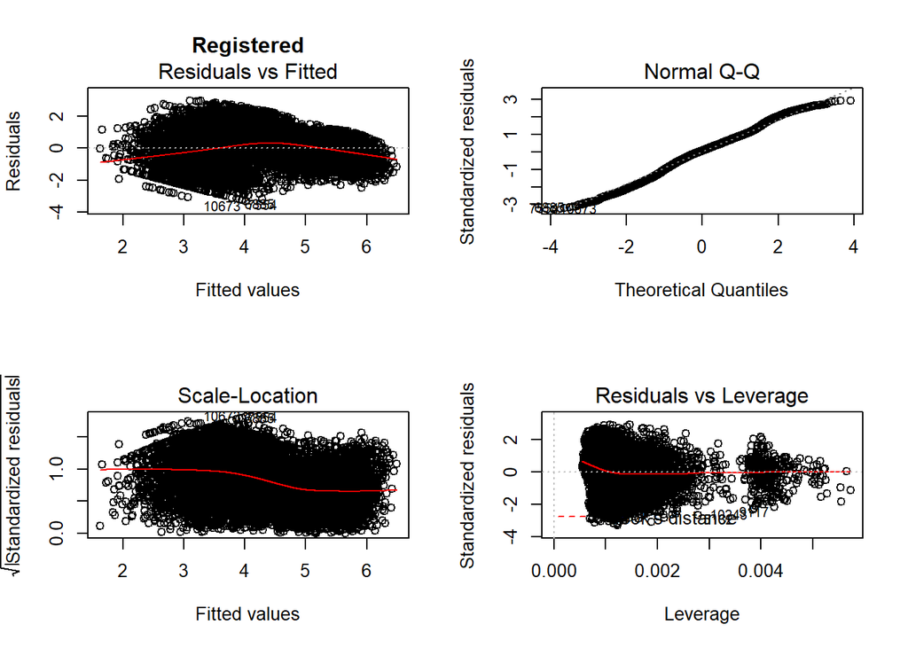

```r
{
    # plot registered
    par(mfrow = c(2, 2))
    plot(registered.final, 1)
    title(main = "Registered")
    plot(registered.final, c(2, 3, 5))
}
```

The fit for `casual` does not seem like it violates many assumptions for a linear regression. The Normal Q-Q plot shows that the model follows the normal curve relatively well, but there is slight deviation from at the tails. In general, the residuals follow the homoscedasticity assumption well, however, we see that the left side of the plot is obviously not homoscedastic since the residuals vs fitted plot shows points following a linear trend and the scale-location plot shows points following a check trend; this seems to be due to some characteristic of the data that I wasn’t able to identify absolutely. Besides this problem with the homoscedacity, there might also be a problem with the secondary cluster of points in the residuals vs leverage. These points seem to indicate that there is a particular group in the model that are being weighted relatively higher than the rest of the points (even though it is just ~.004 leverage).

In the fit for `registered`, it seems to follow the same violations as the `casual` variable, however, it seems to violate homoscedasticity to a lesser extent; we do not see a check pattern in the scale-location plot and points in both the scale-location and residuals vs fitted plots are spread out more evenly. We see also see some linear subtrends in the residuals vs fitted and in the scalelocation, but they are not that prominent. The normal Q-Q plot is very similar to the `casual` regression’s plot, however, we see the right tail of the plot following closer to the normal curve and the left tail of the plot following further from the normal curve. The residuals vs leverage plot also shows a secondary grouping of points with relatively more leverage.